# L4 SVD分解和图像压缩

Wangcheng Li

2023-09-13

# 1 SVD 分解和图像压缩

本节关于理论准备的知识参考了郭老师在群中提供的课件 《奇异值分解md》 和[知乎文章](https://zhuanlan.zhihu.com/p/399547902) 。

## 1.1 SVD分解

谱分解实现了实对称矩阵的对角化，其结果非常优雅。一个自然的问题是非对称矩阵乃至于非方阵的对角化如何实现。这里，SVD分解（奇异值分解）就可以被认为是谱分解的一个推广，它将任意矩阵通过正交变换成为对角矩阵。

### 1.1.1 理论准备

SVD分解是指，对于任意的矩阵 $A_{m\times n}$，有如下分解
$$A_{m\times n} =
U_{m\times m} D_{m\times n} V^T_{n\times n}
= U_{m\times m}
\begin{bmatrix}
D_{r\times r} & 0
\\
0 & 0
\end{bmatrix}
V^T_{n\times n}
\tag{1}$$
其中 $U$ 和 $V$ 均为正交矩阵， $D_r$ 为对角矩阵，对角线元素为 $\sigma_1,\cdots,\sigma_r$ ， $r$ 为矩阵 $A$ 的秩。我们称 $\sigma_1 \ge \sigma_2 \ge \cdots \ge \sigma_r$ 为矩阵 $A$ 的奇异值。

*直观理解*：可以想象，在线性代数中，我们总可以通过有限次行变换和列变换将任意矩阵变形为形如 $D$ 的矩阵。而我们知道，行列变换等价于左乘/右乘一个可逆矩阵。因此直观来看，只要将可逆矩阵进行正交化，就可以得到形如式(1) 的SVD分解。（此处仅为个人理解，仅供参考，如果有错误也可以交流）

*理论证明*：存在性证明通常采用构造性证明思路，此处尝试构造正交矩阵 $U$ , $V$ 和 $D$.

三个准备性的知识：

1. $A^{T}A$ 的特征值总是非负的（即半正定）
2. 如果有 $R^n$ 中的一组正交向量 $e_1,\cdots,e_s\ (s < n)$ ，则总可以将其扩充为 $R^n$ 中的一组正交基 $e_1,\cdots,e_s,\tilde{e}_{s+1},\cdots,\tilde{e}_{n}$。（证明省略）
3. $A^{T}A$ 的秩和 $A$ 相同。

*正式证明*

基于以上，我们考虑矩阵 $A^TA$ 的特征值 $\lambda_1,\cdots,\lambda_r,0,\cdots,0$ ，和相应的特征向量 $\alpha_1,\cdots,\alpha_n$ 。其中 $\lambda_1,\cdots,\lambda_r$ 为 $A^TA$ 的 $r$ 个非负特征值。

进而考虑 $\alpha_i^T A^T A \alpha_j$ 的情况：
$$\alpha_i^T A^T A \alpha_j = \lambda_j \alpha_i^T \alpha_j =
\begin{cases}
\lambda_i, & i = j \le r
\\
0, &\mbox{else}
\end{cases}
\tag{2}$$

此时考虑 $\frac{A\alpha_1}{\sqrt{\lambda_1}},\cdots,\frac{A\alpha_r}{\sqrt{\lambda_r}}$，有(2)式可知，这组向量正交。记 $\frac{A\alpha_i}{\sqrt{\lambda_i}} = u_i$，则容易有以下结论
$$A(\alpha_1,\cdots,\alpha_r)_{n\times r} =
(u_1,\cdots,u_r)_{m \times r}
\begin{bmatrix}
\sqrt{\lambda_1} & & & \cdots\\
& \sqrt{\lambda_2} & & \\
\vdots & & \ddots& \\
& & & \sqrt{\lambda_r}
\end{bmatrix}$$

只需要注意到 $\alpha_i$ 长度为 $n$ ， $u_i$ 长度为 $m$。再将 $\alpha_1,\cdots,\alpha_r$ 拓展至 $\alpha_1,\cdots,\alpha_n$ 。将 $u_1,\cdots,u_r$ 拓展至 $u_1,\cdots,u_m$ 。就得到了矩阵 $U$ $V$ 和 $D$.

### 1.1.3 R语言代码实现

R语言中自带了一个svd分解的函数 `svd` ：

```r
A = matrix(c(1,1,1,1,
             1,1,1,2,
             1,1,1,1),3,4,byrow = T)
# n = 3; p = 10
# A = matrix(sample(1:(10*n*p), n*p), n, p)
a1 = svd(A)
```

```r
require(corpcor) # fast svd for small n, big p
svd_func <- function(A) {
  eig.val <- eigen(t(A)%*%A)$values
  index <- (eig.val > 10e-5)
  eig.val <- eig.val[index]
  d <- sqrt(eig.val)
  v <- eigen(t(A)%*%A)$vectors[,index]
  u <- matrix(NA, nrow(A), length(eig.val))
  for (i in 1:ncol(v)) {
    u[,i] <- (A%*%v[,i])/d[i]
  }
  return(list(d=d, u=u, v=v))
}



svd_func(A)
```

```
## $d
## [1] 3.8195187 0.6413085
##
## $u
##            [,1]       [,2]
## [1,] -0.5173332 -0.4820439
## [2,] -0.6817131  0.7316196
## [3,] -0.5173332 -0.4820439
##
## $v
##            [,1]       [,2]
## [1,] -0.4493706 -0.3624905
## [2,] -0.4493706 -0.3624905
## [3,] -0.4493706 -0.3624905
## [4,] -0.6278520  0.7783327
```

```r
fast.svd(A) # require(corpcor)
```

```
## $d
## [1] 3.8195187 0.6413085
##
## $u
##           [,1]       [,2]
## [1,] 0.5173332  0.4820439
## [2,] 0.6817131 -0.7316196
## [3,] 0.5173332  0.4820439
##
## $v
##           [,1]       [,2]
## [1,] 0.4493706  0.3624905
## [2,] 0.4493706  0.3624905
## [3,] 0.4493706  0.3624905
## [4,] 0.6278520 -0.7783327
```

## 1.2 图像压缩

对三个图层分别进行svd分解。

```r
img <- jpeg::readJPEG("./picture/svd-pic4.jpg")
dim(img)
```

```
## [1] 130 172   3
```

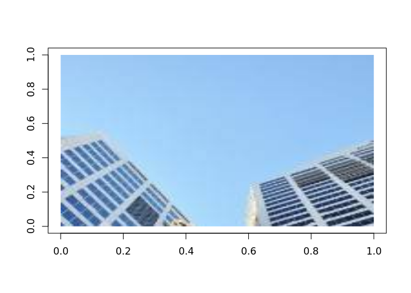

```r
plot(0:1, 0:1, type = "n", xlab = "", ylab = "")
rasterImage(img, 0, 0, 1, 1)
```

```r
svd_1 = svd(img[,,1])
svd_2 = svd(img[,,2])
svd_3 = svd(img[,,3])
```

以图层1为例，我们可以绘制奇异值的变化趋势。可以看到第一个奇异值远大于其余奇异值，而且奇异值序列迅速衰减到接近0。我们同样可以查看其余两个图层的奇异值变化情况。

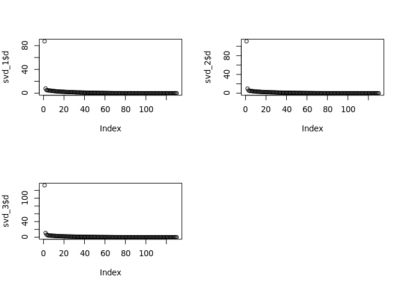

```r
par(mfrow = c(2,2))
plot(svd_1$d)
plot(svd_2$d)
plot(svd_3$d)
par(mfrow = c(1,1))
```

进一步，我们首先使用第一个奇异值对应的向量来重建图像，观察图像的情况。

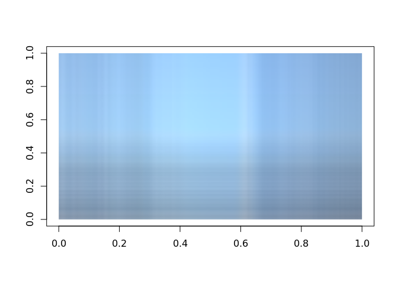

```r
new_img = array(NA,dim = dim(img))
new_img[,,1] = pmax(pmin(svd_1$u[,1,drop = F] %*% svd_1$d[1] %*% t(svd_1$v[,1,drop = F]),1),0)
new_img[,,2] = pmax(pmin(svd_2$u[,1,drop = F] %*% svd_2$d[1] %*% t(svd_2$v[,1,drop = F]),1),0)
new_img[,,3] = pmax(pmin(svd_3$u[,1,drop = F] %*% svd_3$d[1] %*% t(svd_3$v[,1,drop = F]),1),0)

plot(0:1, 0:1, type = "n", xlab = "", ylab = "")
rasterImage(new_img, 0, 0, 1, 1)
```

可以看到，图像像素点的每一行和每一列都有着相似的趋势，这是因为该图像的像素数据的矩阵秩为1。 显然，一个秩为1的矩阵只能显示出色彩的变化趋势，并没有任何细节。因此我们进一步考虑前两个奇异值来重构图像。 为了方便后续使用，我们将重构图像写成一个函数。

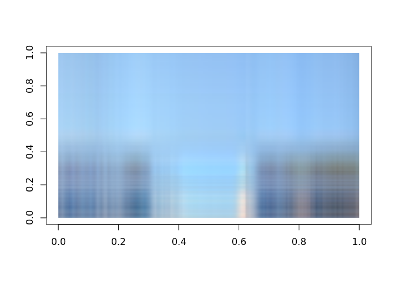

```r
restruct_img = function(m,dimimg,svd_list){

  new_img = array(NA,dim = dimimg)
  new_img[,,1] = pmax(pmin(svd_list[[1]]$u[,1:m,drop = F] %*% diag(svd_list[[1]]$d[1:m]) %*% t(svd_list[[1]]$v[,1:m,drop = F]),1),0)
  new_img[,,2] = pmax(pmin(svd_list[[2]]$u[,1:m,drop = F] %*% diag(svd_list[[2]]$d[1:m]) %*% t(svd_list[[2]]$v[,1:m,drop = F]),1),0)
  new_img[,,3] = pmax(pmin(svd_list[[3]]$u[,1:m,drop = F] %*% diag(svd_list[[3]]$d[1:m]) %*% t(svd_list[[3]]$v[,1:m,drop = F]),1),0)

  return(new_img)
}

img2 = restruct_img(2,dim(img),list(svd_1,svd_2,svd_3))

plot(0:1, 0:1, type = "n", xlab = "", ylab = "")
rasterImage(img2, 0, 0, 1, 1)
```

此时部分细节已经显现出来。我们进一步考虑更大的m，例如10.

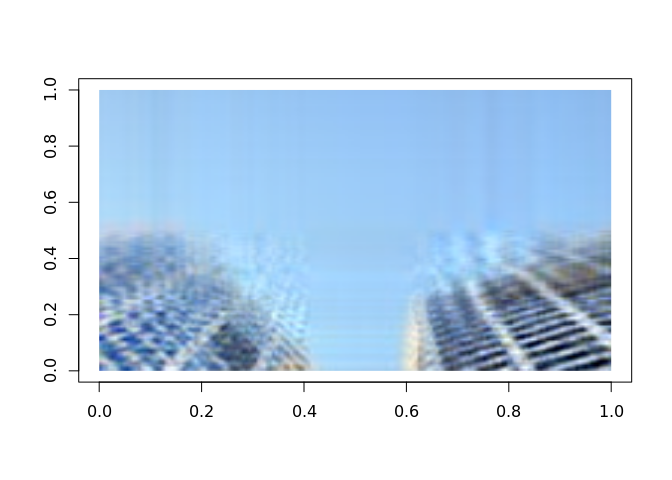

```r
img10 = restruct_img(10,dim(img),list(svd_1,svd_2,svd_3))

plot(0:1, 0:1, type = "n", xlab = "", ylab = "")
rasterImage(img10, 0, 0, 1, 1)
```

那么选择怎样的m比较合适呢，一个选择是不断调整m，直到图像清晰。但图像清晰的标准是比较主观的，因此我们可以考虑用奇异值作为一个判断指标。我们绘制奇异值的累积贡献图：

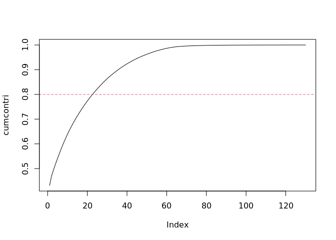

```r
cumcontri = cumsum(svd_1$d)/sum(svd_1$d)
plot(cumcontri,type = "l")
abline(h = 0.8,col = 2,lty = 2)
```

可以看到，在20附近，结果已经接近0.8，可以认为前20个奇异值贡献了接近80%的信息。以0.8为界选择奇异值个数并绘制图像：

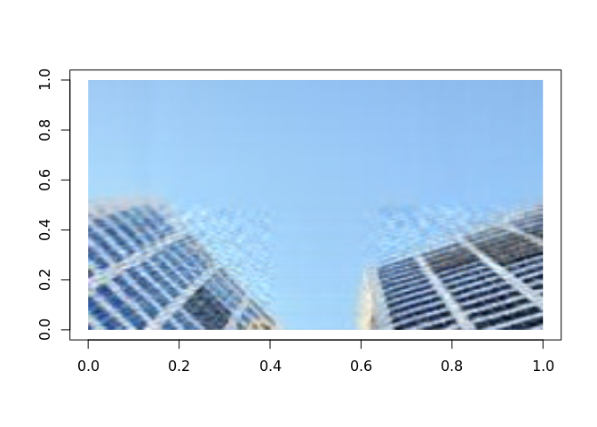

```r
imgcc = restruct_img(min(which(cumcontri > 0.8)),dim(img),list(svd_1,svd_2,svd_3))

plot(0:1, 0:1, type = "n", xlab = "", ylab = "")
rasterImage(imgcc, 0, 0, 1, 1)
```

可以看到，此时大楼的整体轮廓已经恢复的差不多了。

查看此时存储信息的大小：

```r
m = min(which(cumcontri > 0.8))
tep = list(
  svd_1$d[1:m],svd_1$u[,1:m],svd_1$v[,1:m],
  svd_2$d[1:m],svd_2$u[,1:m],svd_2$v[,1:m],
  svd_3$d[1:m],svd_3$u[,1:m],svd_3$v[,1:m]
)
print(object.size(tep));print(object.size(img))
```

```
## 168872 bytes
```

```
## 536864 bytes
```

## 1.3 练习

- 自己选择一张图像来利用svd方法降维
- 自行编写程序，以求解矩阵 $A$ 的加号逆 $A^{+}$